# ShroomsMarkdown

TBoday

2017 március 19

# Mushroom classification

dataset used from https://www.kaggle.com/uciml/mushroom-classification/downloads/mushrooms.csv

This is a true *classic* by all means. A fairly old database, which is available since the 70-es.

# Let’s start with the basics

Initializing the environment, and loading libraries

```r
library(ggplot2)
library(readr)
library(caret)
library(randomForest)
library(caTools)
library(rpart.plot)
library(rattle)
library(gbm)
library(survival)
library(plyr)
```

Loading the dataset

```r
shrooms01<-read.csv("D:/Drive/!CEU/Data Science/Project/input/mushrooms.csv")
```

# A tiny bit of EDA

Although the data set is known for it’s cleanliness I start with some assesment

First check of the contents for obvious issues

```r
summary(shrooms01)
```

```
##  class    cap.shape cap.surface   cap.color    bruises       odor
##  e:4208   b: 452    f:2320      n      :2284   f:4748   n      :3528
##  p:3916   c:   4    g:   4      g      :1840   t:3376   f      :2160
##           f:3152    s:2556      e      :1500            s      : 576
##           k: 828    y:3244      y      :1072            y      : 576
##           s:  32                w      :1040            a      : 400
##           x:3656                b      : 168            l      : 400
##                                 (Other): 220            (Other): 484
##  gill.attachment gill.spacing gill.size   gill.color   stalk.shape
##  a: 210          c:6812       b:5612    b      :1728   e:3516
##  f:7914          w:1312       n:2512    p      :1492   t:4608
##                                         w      :1202
##                                         n      :1048
##                                         g      : 752
##                                         h      : 732
##                                         (Other):1170
##  stalk.root stalk.surface.above.ring stalk.surface.below.ring
##  ?:2480     f: 552                   f: 600
##  b:3776     k:2372                   k:2304
##  c: 556     s:5176                   s:4936
##  e:1120     y:  24                   y: 284
##  r: 192
##
##
##  stalk.color.above.ring stalk.color.below.ring veil.type veil.color
##  w      :4464           w      :4384           p:8124    n:  96
##  p      :1872           p      :1872                     o:  96
##  g      : 576           g      : 576                     w:7924
##  n      : 448           n      : 512                     y:   8
##  b      : 432           b      : 432
##  o      : 192           o      : 192
##  (Other): 140           (Other): 156
##  ring.number ring.type spore.print.color population habitat
##  n:  36      e:2776    w      :2388      a: 384     d:3148
##  o:7488      f:  48    n      :1968      c: 340     g:2148
##  t: 600      l:1296    k      :1872      n: 400     l: 832
##              n:  36    h      :1632      s:1248     m: 292
##              p:3968    r      :  72      v:4040     p:1144
##                        b      :  48      y:1712     u: 368
##                        (Other): 144                 w: 192
```

Plotting does not help either

```r
#plot(shrooms01) # removed due to unusable and computing intensive output
```

Let’s try in a different way, and calculate number of classes for each variable

```r
z<-cbind.data.frame(Var=names(shrooms01), Total_Class=sapply(shrooms01,function(x){as.numeric(length(levels(x)))}))
print(z)
```

```
##                                               Var Total_Class
## class                                       class           2
## cap.shape                               cap.shape           6
## cap.surface                           cap.surface           4
## cap.color                               cap.color          10
## bruises                                   bruises           2
## odor                                         odor           9
## gill.attachment                   gill.attachment           2
## gill.spacing                         gill.spacing           2
## gill.size                               gill.size           2
## gill.color                             gill.color          12
## stalk.shape                           stalk.shape           2
## stalk.root                             stalk.root           5
## stalk.surface.above.ring stalk.surface.above.ring           4
## stalk.surface.below.ring stalk.surface.below.ring           4
## stalk.color.above.ring     stalk.color.above.ring           9
## stalk.color.below.ring     stalk.color.below.ring           9
## veil.type                               veil.type           1
## veil.color                             veil.color           4
## ring.number                           ring.number           3
## ring.type                               ring.type           5
## spore.print.color               spore.print.color           9
## population                             population           6
## habitat                                   habitat           7
```

The only parameter what has no variability (it has only one level) is veil.type.

Seems logical to drop it from the analysis as it would not affect the results

```r
shrooms01$veil.type<-NULL
```

Generating subsets of data

Separating 75% to train, and 25% to test predictions

```r
set.seed(123)

N <- nrow(shrooms01)
idx <- sample(1:N, 0.75*N)
x_train <- shrooms01[idx,]
x_test <- shrooms01[-idx,]


y_train<-x_train$class
y_test <- x_test$class
```

Here I make sure that the actual class (edible or not) is dropped from the test data

```r
x_train$class<-NULL
x_test$class<-NULL
```

Bagging

```r
cv.5.folds<-createMultiFolds(y_train,k=5,times=2)
control.5<-trainControl(method="repeatedcv",number=5,repeats=2,index=cv.5.folds)


cv.10.folds<-createMultiFolds(y_train,k=10,times=2)
control.10<-trainControl(method="repeatedcv",number=10,repeats=2,index=cv.10.folds)
```

# Let’s build some decision trees with Rpart function of caret first

```r
Model1 <-train(x=x_train,y=y_train,method="rpart",trControl=control.5,tuneLength=10)
```

Plots of parameter importance and the trained tree

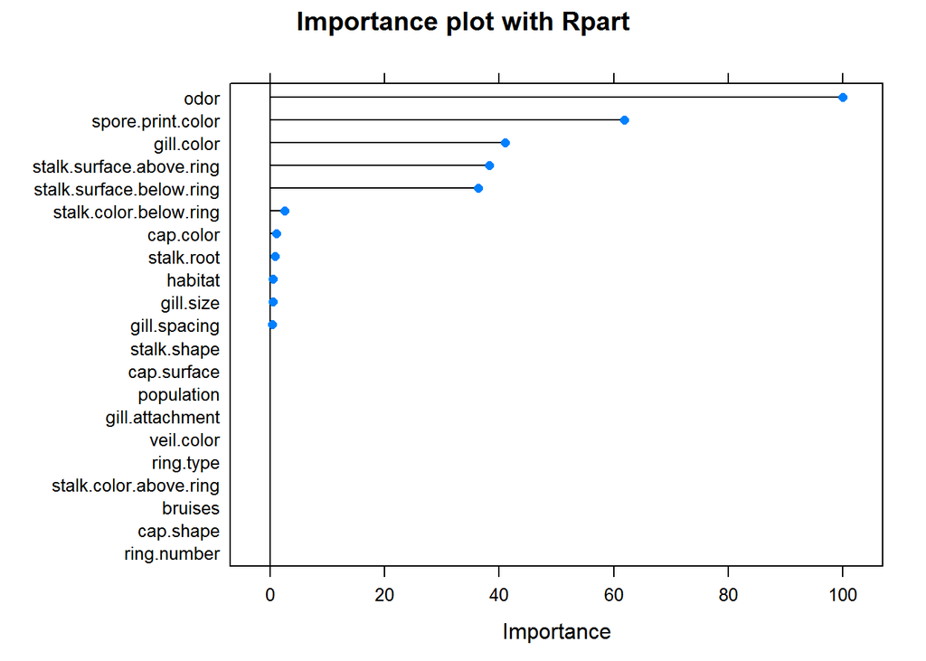

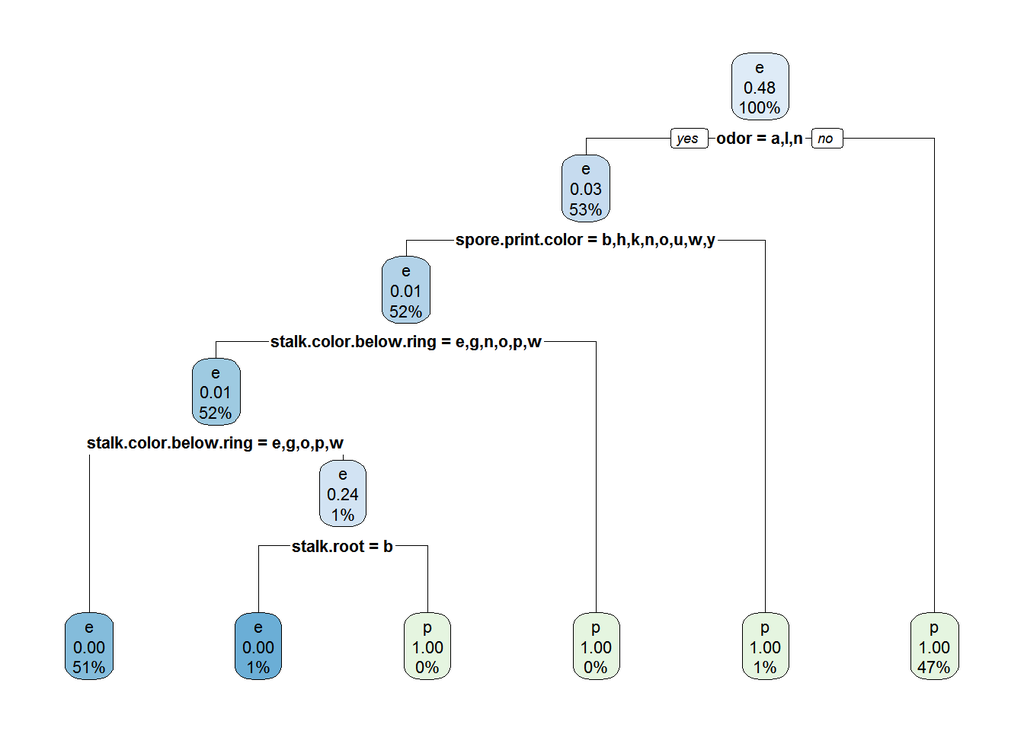

And the confusion matrix for the trained model

```r
y_predicted<-predict(Model1,x_test)

df1<-data.frame(Orig=y_test,Pred=y_predicted)

confusionMatrix(table(df1$Orig,df1$Pred))
```

```
## Confusion Matrix and Statistics
##
##
##        e    p
##   e 1049    0
##   p    3  979
##
##                Accuracy : 0.9985
##                  95% CI : (0.9957, 0.9997)
##     No Information Rate : 0.518
##     P-Value [Acc > NIR] : <2e-16
##
##                   Kappa : 0.997
##  Mcnemar's Test P-Value : 0.2482
##
##             Sensitivity : 0.9971
##             Specificity : 1.0000
##          Pos Pred Value : 1.0000
##          Neg Pred Value : 0.9969
##              Prevalence : 0.5180
##          Detection Rate : 0.5165
##    Detection Prevalence : 0.5165
##       Balanced Accuracy : 0.9986
##
##        'Positive' Class : e
##
```

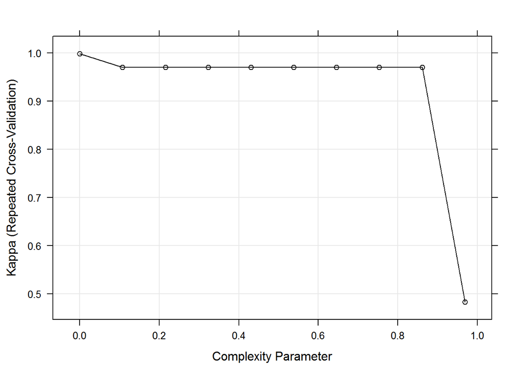

```r
trellis.par.set(caretTheme())
plot(Model1, metric = "Kappa")
```

```r
gbmGrid <-  expand.grid(interaction.depth = c(1, 2, 3, 4, 5, 7, 9),
                        n.trees = (1:30)*50,
                        shrinkage = 0.1,
                        n.minobsinnode = 20)

nrow(gbmGrid)

set.seed(123)
gbmFit2 <- train(class ~ ., data = x_train,
                 method = "gbm",
                 trControl = fitControl,
                 verbose = FALSE,
                 tuneGrid = gbmGrid)
gbmFit2
```

*note to self* further work with Evaluation of Parameters

currently getting error message from caret as data model is not a matrix

```r
matrix_train <- as.matrix(x_train)

ctrl <- trainControl(method = "repeatedcv", repeats = 3, classProbs = TRUE, summaryFunction = twoClassSummary)

#plsFit <- train(Class ~ ., data = model.matrix(x_train), method = "pls", tuneLength = 15, trControl = ctrl, metric = "ROC", preProc = c("center", "scale"))

plsFit <- train(Class ~ ., data = x_train, method = "pls", tuneLength = 15, trControl = ctrl, metric = "ROC", preProc = c("center", "scale")) # getting object is not a  matrix error


plsClasses <- predict(plsFit, newdata = x_test)
str(plsClasses)
plot(plsFit)
```

```r
Model1 <-train(x=x_train,y=y_train,method="rpart",trControl=control.5,tuneLength=5)
```

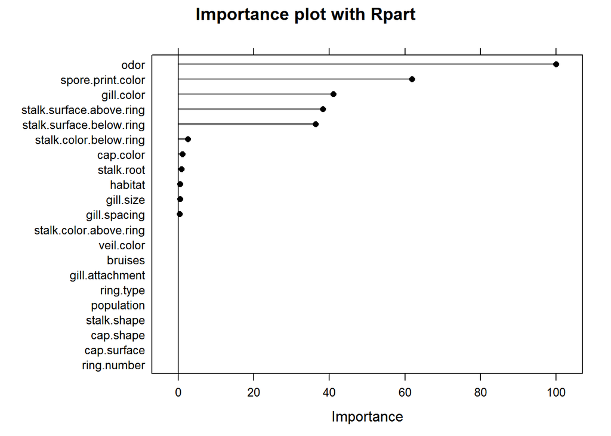

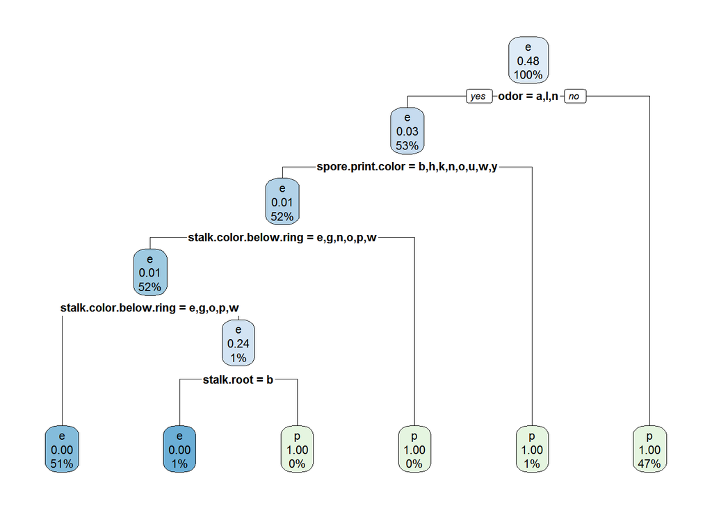

```r
y_predicted<-predict(Model1,x_test)

df1<-data.frame(Orig=y_test,Pred=y_predicted)

confusionMatrix(table(df1$Orig,df1$Pred))
```

```
## Confusion Matrix and Statistics
##
##
##        e    p
##   e 1049    0
##   p    3  979
##
##                Accuracy : 0.9985
##                  95% CI : (0.9957, 0.9997)
##     No Information Rate : 0.518
##     P-Value [Acc > NIR] : <2e-16
##
##                   Kappa : 0.997
##  Mcnemar's Test P-Value : 0.2482
##
##             Sensitivity : 0.9971
##             Specificity : 1.0000
##          Pos Pred Value : 1.0000
##          Neg Pred Value : 0.9969
##              Prevalence : 0.5180
##          Detection Rate : 0.5165
##    Detection Prevalence : 0.5165
##       Balanced Accuracy : 0.9986
##
##        'Positive' Class : e
##
```

# Training a random Forest model

```r
RandomForest.5.cv<-train(x=x_train,y=y_train,method="rf",trControl=control.5,tuneLength=2)
```

Let’s see what we got here

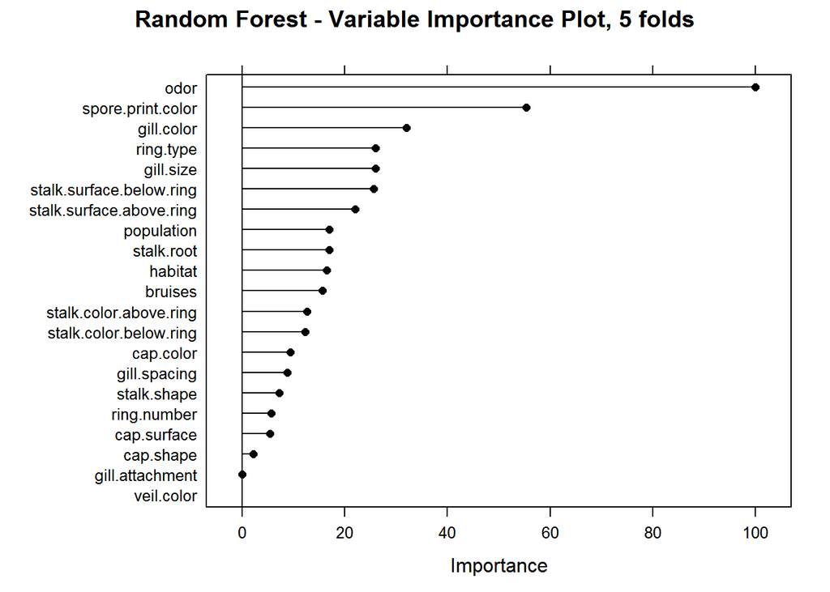

```r
plot(varImp(RandomForest.5.cv),main="Random Forest - Variable Importance Plot, 5 folds")
```

This is what we get whet trying on the test sample

```r
y_predicted<-predict(RandomForest.5.cv,x_test)

df5<-data.frame(Orig=y_test,Pred=y_predicted)

confusionMatrix(table(df5$Orig,df5$Pred))
```

```
## Confusion Matrix and Statistics
##
##
##        e    p
##   e 1049    0
##   p    0  982
##
##                Accuracy : 1
##                  95% CI : (0.9982, 1)
##     No Information Rate : 0.5165
##     P-Value [Acc > NIR] : < 2.2e-16
##
##                   Kappa : 1
##  Mcnemar's Test P-Value : NA
##
##             Sensitivity : 1.0000
##             Specificity : 1.0000
##          Pos Pred Value : 1.0000
##          Neg Pred Value : 1.0000
##              Prevalence : 0.5165
##          Detection Rate : 0.5165
##    Detection Prevalence : 0.5165
##       Balanced Accuracy : 1.0000
##
##        'Positive' Class : e
##
```

```r
#trellis.par.set(caretTheme())
#plot(RandomForest.5.cv, metric = "Kappa") #got to check these for future reference
```

Let’s have a look also on a 10 fold data.

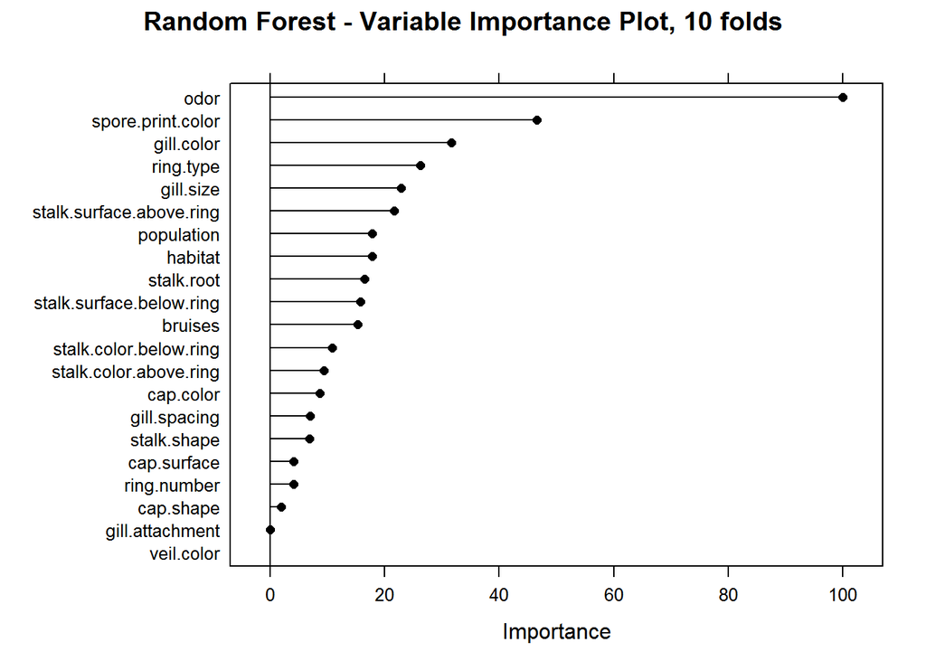

```r
RandomForest.10.cv<-train(x=x_train,y=y_train,method="rf",trControl=control.10,tuneLength=2)

plot(varImp(RandomForest.10.cv),main="Random Forest - Variable Importance Plot, 10 folds")
```

```r
y_predicted<-predict(RandomForest.10.cv,x_test)

df10<-data.frame(Orig=y_test,Pred=y_predicted)

confusionMatrix(table(df10$Orig,df10$Pred))
```

```
## Confusion Matrix and Statistics
##
##
##        e    p
##   e 1049    0
##   p    0  982
##
##                Accuracy : 1
##                  95% CI : (0.9982, 1)
##     No Information Rate : 0.5165
##     P-Value [Acc > NIR] : < 2.2e-16
##
##                   Kappa : 1
##  Mcnemar's Test P-Value : NA
##
##             Sensitivity : 1.0000
##             Specificity : 1.0000
##          Pos Pred Value : 1.0000
##          Neg Pred Value : 1.0000
##              Prevalence : 0.5165
##          Detection Rate : 0.5165
##    Detection Prevalence : 0.5165
##       Balanced Accuracy : 1.0000
##
##        'Positive' Class : e
##
```

# Model 3 GBM

```r
Model3<-train(x=x_train,y=y_train,method="gbm", trControl=control.5,tuneLength=3,verbose=FALSE)
```

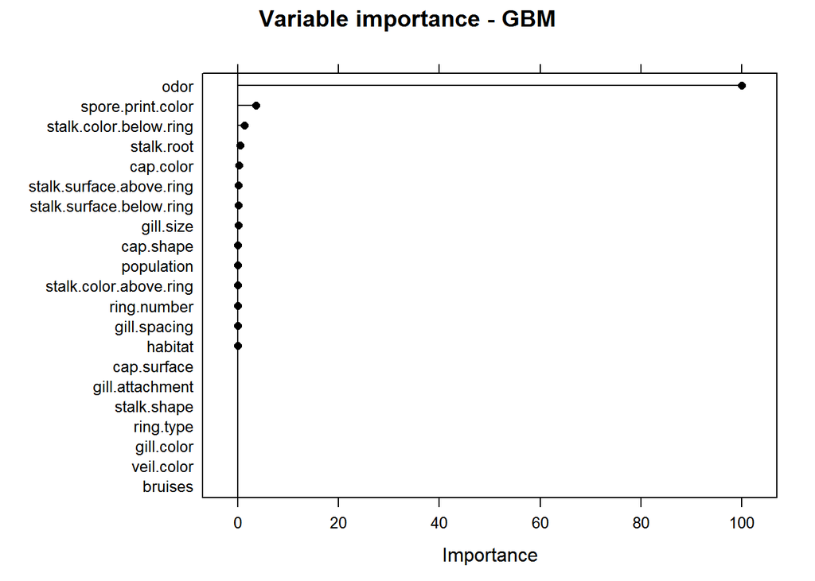

```
## Confusion Matrix and Statistics
##
##
##        e    p
##   e 1049    0
##   p    0  982
##
##                Accuracy : 1
##                  95% CI : (0.9982, 1)
##     No Information Rate : 0.5165
##     P-Value [Acc > NIR] : < 2.2e-16
##
##                   Kappa : 1
##  Mcnemar's Test P-Value : NA
##
##             Sensitivity : 1.0000
##             Specificity : 1.0000
##          Pos Pred Value : 1.0000
##          Neg Pred Value : 1.0000
##              Prevalence : 0.5165
##          Detection Rate : 0.5165
##    Detection Prevalence : 0.5165
##       Balanced Accuracy : 1.0000
##
##        'Positive' Class : e
##
```

# Evaluation

Comparing the the above three models is fairly difficult in this specific case.

It is apparent, that in the given dataset Odor was the strongest proxy, that alone predicts the class close to 100%

Therefore being all other things equal, I’d select the one what has the least computing requirement for avaluations.